# Does Econ Augment matter for Tft Economy

## Gold amount at 4-2

My curiosity in this topic all started when I was scrolling through the leaderboard on tft to see what other challenger players were using in their games and I came across a Korean top 100 player using the same team in every match and having a very high success rate with it so I decided to see if sacrificing early game power for an economy augment actually pay off? This box plot here shows the distribution of my results and shows that games with a economy augment do tend to reach a much higher economy augment total, proving that it provides a significant resource advantage for the mid-game board transition.

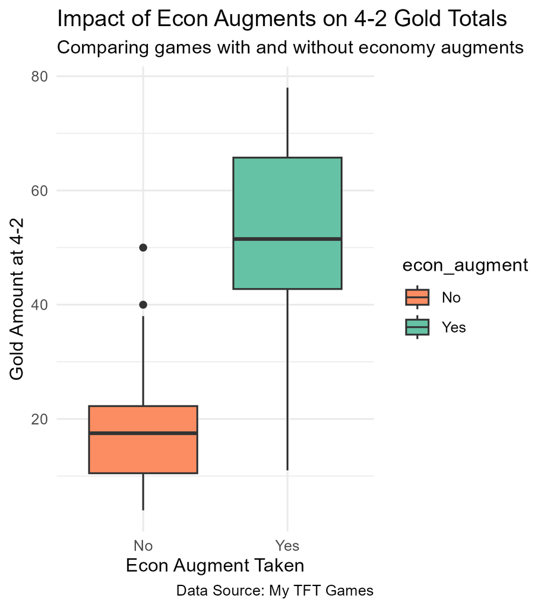

## Data Collection timeline

To see if these results were just a “lucky streak” or a consistent trend, I mapped my gold totals over the entire collection period using the lubridate package. This scatter plot shows the chronological order of progression of my matches. By visualising the data this way, I can see that the higher gold peaks are not random and that they consistently align with games where an economy augment was active, regardless of the date the match was played.

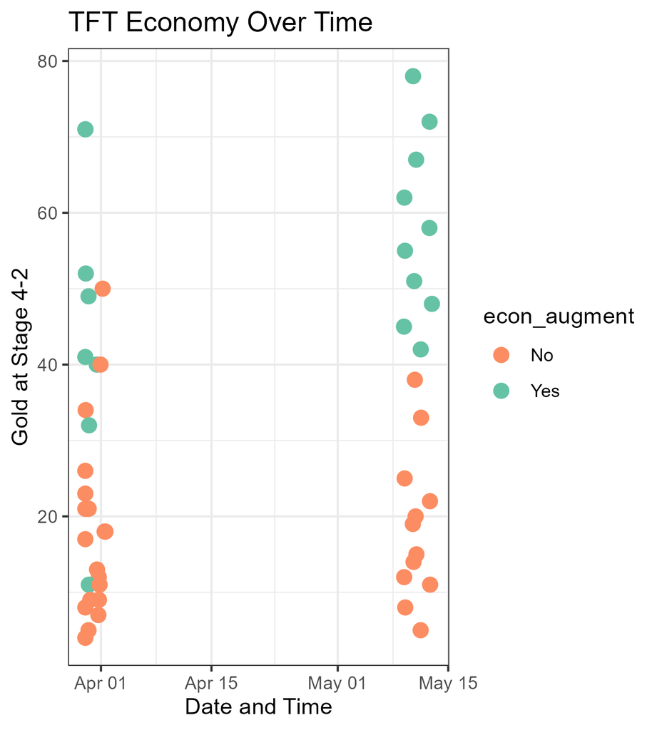

## The Final Economic Average

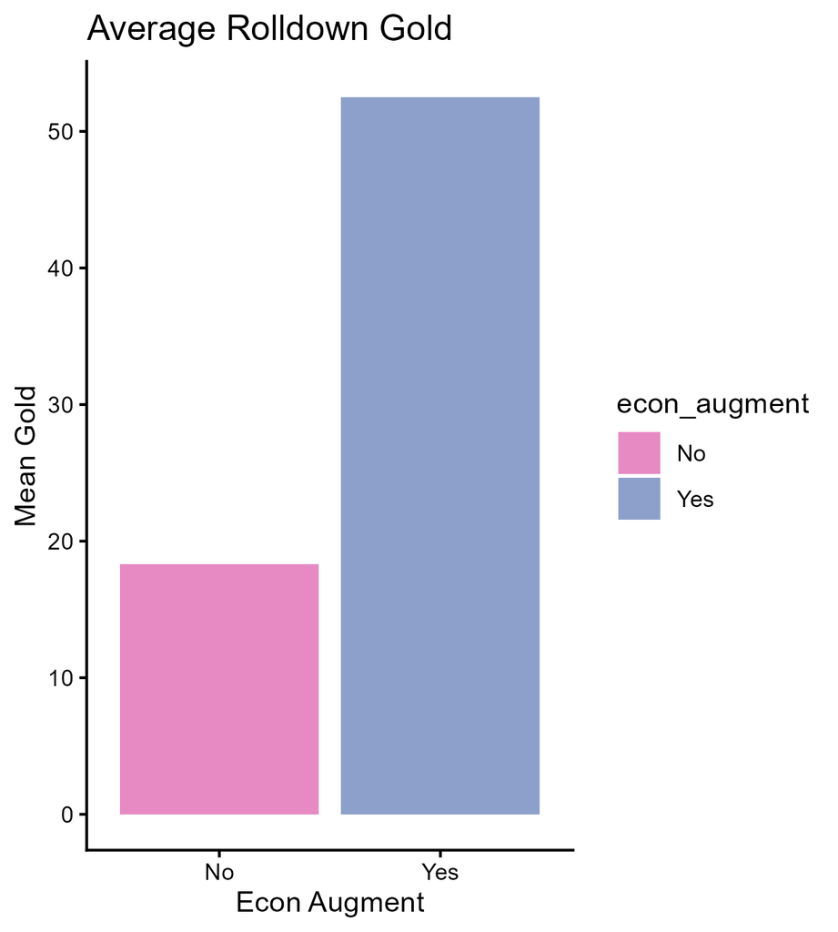